# Parallel Processing

## Introduction

## Serial Computing

Most (legacy) software is written for serial computation:

- Problem broken into discrete set of instructions
- Instructions executed sequentially on a single processor

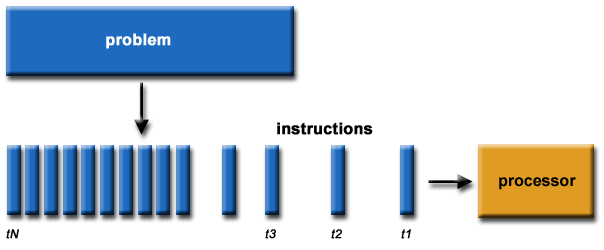

Figure from [here](https://computing.llnl.gov/tutorials/parallel_comp/)

## Parallel computation

- Problem divided into discrete parts that can be solved concurrently
- Instructions executed simultaneously on different processors
- Overall control/coordination mechanism

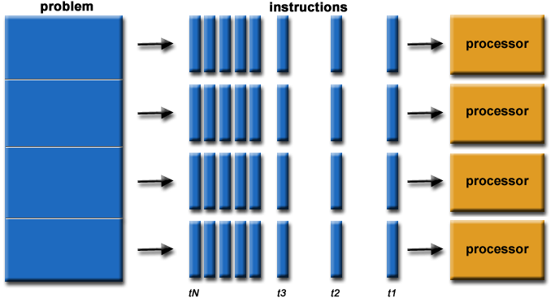

Figure from [here](https://computing.llnl.gov/tutorials/parallel_comp/)

## Flynn's taxonomy

A classification of computer architectures ([Flynn, 1972](http://dx.doi.org/10.1109/TC.1972.5009071))

### Four Categories

1. *Single Instruction, Single Data (SISD)*
   - No parallelization
2. *Single Instruction, Multiple Data (SIMD)*
   - Run the same code/analysis on different datasets
   - Examples:
     - different species in species distribution model

*Multiple Instruction, Single Data (MISD)*

- Run different code/analyses on the same data
- Examples:
  - One species, multiple models

*Multiple Instruction, Multiple Data streams (MIMD)*

- Run different code/analyses on different data
- Examples:
  - Different species & different models

## Flynn's Taxonomy

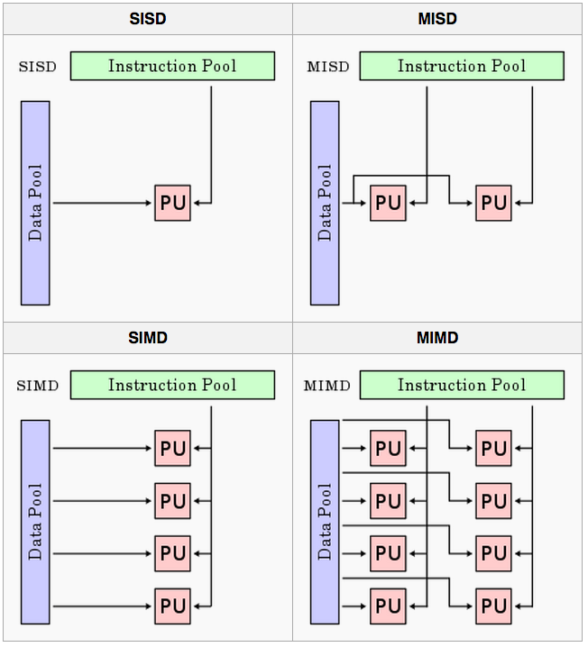

Figure from [here](http://en.wikipedia.org/wiki/Flynn%27s_taxonomy)

## Our focus: *Single Instruction, Multiple Data (SIMD)*

1. Parallel functions within an R script
   - starts on single processor
   - runs looped elements on multiple 'slave' processors
   - returns results of all iterations to the original instance
   - foreach, multicore, plyr, raster
2. Alternative: run many separate instances of R in parallel with `Rscript`
   - need another operation to combine the results
   - preferable for long, complex jobs
   - NOT planning to discuss in this session

## R Packages

There are many R packages for parallelization, check out the CRAN Task View on [High-Performance and Parallel Computing](http://cran.r-project.org/web/views/HighPerformanceComputing.html) for an overview. For example:

- [Rmpi](http://cran.r-project.org/web/packages/Rmpi/index.html): Built on MPI (Message Passing Interface), a de facto standard in parallel computing.
- [snow](http://cran.r-project.org/web/packages/snow/index.html): Simple Network of Workstations can use several standards (PVM, MPI, NWS)
- [parallel](https://stat.ethz.ch/R-manual/R-devel/library/parallel/doc/parallel.pdf) Built in R package (since v2.14.0).

## Foreach Package

In this session we'll focus on the foreach package, which has numerous advantages including:

- intuitive `for()` loop-like syntax
- flexibility of parallel 'backends' from laptops to supercomputers (`multicore`, `parallel`, `snow`, `Rmpi`, etc.)
- nice options for combining output from parallelized jobs

## Documentation for foreach:

- [foreach manual](http://cran.r-project.org/web/packages/foreach/foreach.pdf)
- [foreach vignette](http://cran.r-project.org/web/packages/foreach/vignettes/foreach.pdf)
- [Nested Loops](http://cran.r-project.org/web/packages/foreach/vignettes/nested.pdf)

### Foreach *backends*

- [doParallel](http://cran.r-project.org/web/packages/doParallel/index.html) best for use on multicore machines (uses `fork` on linux/mac and `snow` on windows).
- [doMPI](http://cran.r-project.org/web/packages/doMPI/vignettes/doMPI.pdf): Interface to MPI (Message-Passing Interface)
- [doSNOW](http://cran.r-project.org/web/packages/doSNOW/doSNOW.pdf): Simple Network of Workstations